# Traffic Light Detection and Classification

### by Wenzhe Ding

In this project, I'll create a traffic light classier that can identify the state of a traffic light using [Tensorflow Object Detection API](https://github.com/tensorflow/models/tree/master/research/object_detection). This API provides a few pre-trained models which are capable of identifying a traffic light in an image, but not it’s state (green, yellow, red, etc). My classifier will be able to both detect a traffic light and classify the color of it in an image and a video.

- Introduction
- Data Source
- Traffic Light Detection
- Traffic Light Detection and Classification
  - 1. Select a model
  - 2. Generate training and validation sets
  - 3. Update the model configuration
  - 4. Model training
  - 5. Freeze the best model
  - 6. Model evaluation
- Testing on videos
  - Image to Video
  - Video Pipeline
- Resources

```python
import numpy as np
import pandas as pd
import tensorflow as tf
import os

from matplotlib import pyplot as plt
from PIL import Image, ImageDraw, ImageColor

import warnings
warnings.filterwarnings('ignore')

%matplotlib inline
```

## Introduction

[ go back to the top ]

Steps that we used to classify the color of a traffic light in an image using Tensorflow Object Detection API:

- Collect a few hundred images that contain traffic light.
- Annotate/label the images. For this project, I used eye labeling the color of the traffic light.
- Use Tensorflow Object Detection API to draw bounding boxes around traffic lights in an image.
- Split this data into train/val/test samples
- Generate TF Records from these splits
- Setup a .config file for the model of choice
- Train
- Export graph from new trained model
- Detect custom objects in a video!

## Data Source

[ go back to the top ]

- Udacity Camera Feed (3.49 GB compressed files)

These images became available on August 24th over the slack channel #p-system-integration. It contains two bag files with an image feed from the Udacity self-driving car's camera in the test lot and a topic containing the car's position at [google drive](https://drive.google.com/file/d/0B2_h37bMVw3iYkdJTlRSUlJIamM/view?usp=sharing).

Using the command line below to extract color images from bag files and save all files in a folder, the python script can be downloaded here:

`python script/bag_to_images.py just_traffic_light.bag just_traffic_light/`

`python script/bag_to_images.py loop_with_traffic_light.bag loop_with_traffic_light/`

```python
src_dir_1 = 'Capstone/just_traffic_light'
src_dir_2 = 'Capstone/loop_with_traffic_light'
# Size, in inches, of the output images.
IMAGE_SIZE = (15, 8)
```

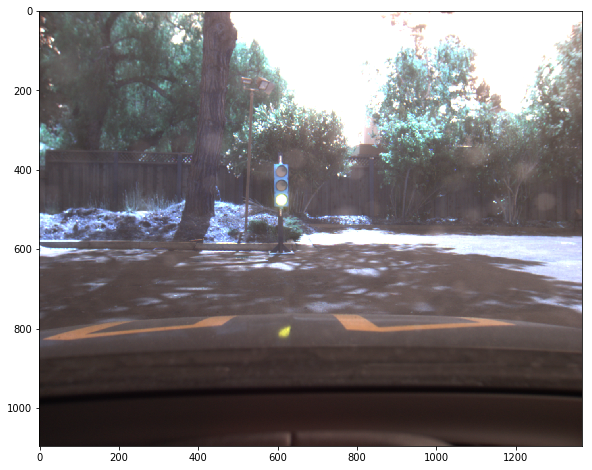

```python
udacity_train = src_dir_1 + '/frame000340.png'
image = Image.open(udacity_train)
plt.figure(figsize=IMAGE_SIZE)
plt.imshow(image)
```

Note that some images do not contain a traffic light. See an example below.

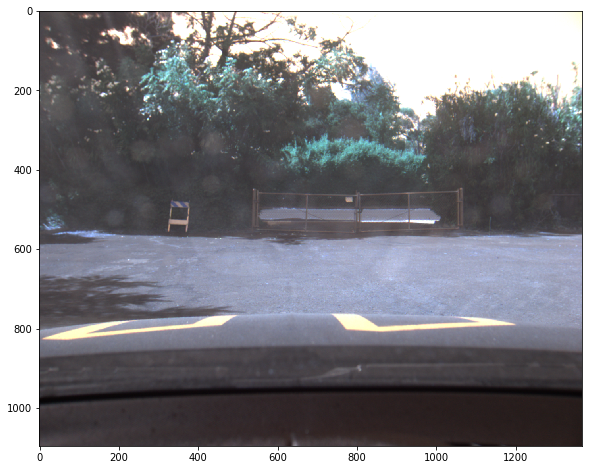

```python
udacity_train = src_dir_2 + '/frame000000.png'
image = Image.open(udacity_train)
plt.figure(figsize=IMAGE_SIZE)
plt.imshow(image)
```

## Traffic Light Detection

[ go back to the top ]

There are a few models can be downloaded from the [TensorFlow detection model zoo](https://github.com/tensorflow/models/blob/master/research/object_detection/g3doc/detection_model_zoo.md). In this project, we used a Faster RCNN model, which can be downloaded from [here](http://download.tensorflow.org/models/object_detection/faster_rcnn_inception_resnet_v2_atrous_coco_2018_01_28.tar.gz) (746.4 MB). Label maps map indices to category names, so that when our convolution network predicts 10, we know that this corresponds to traffic lights. Label maps can be downloaded [here](https://github.com/tensorflow/models/tree/master/research/object_detection/data). Files in the `faster_rcnn_inception_resnet_v2_atrous_coco_2018_01_28` folder are shown below. Note that we put the label map in the sample folder.

Also, We downloaded all files in folder research and only kept all the needed files for our purposes. Two files - `label_map_util.py`, `visualization_utils.py` - will be used in this section and more files will be used in the next section.

```python
import visualization_utils as vis_util
import label_map_util
test_images = [os.path.join(src_dir_1,'frame00030{}.png'.format(i)) for i in range(1) ]
```

```python
src_dir = 'tensorflow/research/object_detection/'
FASTER_RCNN = src_dir + 'models/faster_rcnn_inception_resnet_v2_atrous_coco_2018_01_28/'
FASTER_RCNN_GRAPH_FILE = FASTER_RCNN + 'frozen_inference_graph.pb'
```

```python
print("Files extracted from compressed .tar.gz file:\n")
for file in os.listdir(FASTER_RCNN):
    print(file)
```

```
Files extracted from compressed .tar.gz file:

frozen_inference_graph.pb
.ipynb_checkpoints
model.ckpt.data-00000-of-00001
saved_model
pipeline.config
model.ckpt.index
checkpoint
mscoco_label_map.pbtxt
model.ckpt.meta
```

Now we want to load the graph and do traffic light detection on our data.

```python
# we put it in the same directory as the model directory
PATH_TO_LABELS = FASTER_RCNN + 'mscoco_label_map.pbtxt'
GRAPH_FILE = FASTER_RCNN_GRAPH_FILE
NUM_CLASSES = 90

class Classifier(object):
    def __init__(self):
        label_map = label_map_util.load_labelmap(PATH_TO_LABELS)
        categories = label_map_util.convert_label_map_to_categories(label_map,
                                                     max_num_classes=NUM_CLASSES,
                                                    use_display_name=True)
        self.category_index = label_map_util.create_category_index(categories)
        """Loads a frozen inference graph"""
        self.detection_graph = tf.Graph()
        with self.detection_graph.as_default():
            od_graph_def = tf.GraphDef()
            with tf.gfile.GFile(GRAPH_FILE, 'rb') as fid:
                serialized_graph = fid.read()
                od_graph_def.ParseFromString(serialized_graph)
                tf.import_graph_def(od_graph_def, name='')
            self.image_tensor = self.detection_graph.get_tensor_by_name('image_tensor:0')
            self.d_boxes = self.detection_graph.get_tensor_by_name('detection_boxes:0')
            self.d_scores = self.detection_graph.get_tensor_by_name('detection_scores:0')
            self.d_classes = self.detection_graph.get_tensor_by_name('detection_classes:0')
            self.num_d = self.detection_graph.get_tensor_by_name('num_detections:0')
        self.sess = tf.Session(graph=self.detection_graph)

    def load_image_into_numpy_array(self, image):
        (im_width, im_height) = image.size
        return np.array(image.getdata()).reshape((im_height, im_width, 3)).astype(np.uint8)

    def get_classification(self, img):
        image = self.load_image_into_numpy_array(img)
        # Bounding Box Detection.
        with self.detection_graph.as_default():
            # Expand dimension since the model expects image to have shape [1, None, None, 3].
            img_expanded = np.expand_dims(img, axis=0)
            (boxes, scores, classes, num) = self.sess.run(
                [self.d_boxes, self.d_scores, self.d_classes, self.num_d],
                feed_dict={self.image_tensor: img_expanded})
            boxes = np.squeeze(boxes)
            scores = np.squeeze(scores)
            classes = np.squeeze(classes).astype(np.int32)

        vis_util.visualize_boxes_and_labels_on_image_array(
                image, boxes, classes, scores,
                self.category_index,
                use_normalized_coordinates=True,
                line_thickness=8)
        plt.figure(figsize=IMAGE_SIZE)
        plt.imshow(image)
        return
```

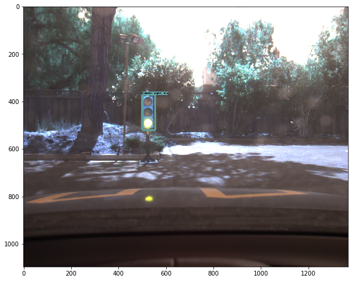

```python
class1 = Classifier()
class1.get_classification(Image.open(test_images[0]))
```

This pretrained model can detect traffic lights well in the image, one example detection is shown above. That question is, how do I modify the pre-trained model that was designed to work on the 90 classes of the COCO dataset, to work on the X number of classes of my new dataset? The next part will focus on solving this problem.

## Traffic Light Detection and Classification

[ go back to the top ]

We followed the installation instruction [here](https://github.com/tensorflow/models/blob/master/research/object_detection/g3doc/installation.md) to install necessary packages. Also, this post on Medium is helpful for us to use Tensorflow Object Detection API to train our own model. We encoutered two issues during the installation and using the API and the solutions are shown below:

**Use protoc-3.2.0 rather than 2.6.1** , use the command line below to uninstall protoc-2.6.1 and install protoc-3.2.0

```
sudo apt-get remove protobuf-compiler

curl -OL https://github.com/google/protobuf/releases/download/v3.2.0/protoc-3.2.0-linux-x86_64.zip

unzip protoc-3.2.0-linux-x86_64.zip -d protoc3

sudo mv protoc3/bin/* /usr/local/bin/

sudo mv protoc3/include/* /usr/local/include/
```

**Python3 incompatibility issue** , need to modify models/research/object_detection/utils/learning_schedules.py lines 167-169. Currently it is

```
`rate_index = tf.reduce_max(tf.where(tf.greater_equal(global_step, boundaries),
                                      range(num_boundaries),
                                      [0] * num_boundaries))`

Wrap list() around the range() like this:

`rate_index = tf.reduce_max(tf.where(tf.greater_equal(global_step, boundaries),
                                     list(range(num_boundaries)),
                                      [0] * num_boundaries))`
```

The detailed steps of using the API is shown below.

### 1. Select a model

[ go back to the top ]

In this project, we select the same Faster RCNN model which is used in the first part.

[ go back to the top ]

We followed the API instruction on how to create .record files from image dataset and the [data requirement](https://github.com/tensorflow/models/blob/master/research/object_detection/g3doc/using_your_own_dataset.md) is showned below:

For every example in the dataset, we should have the following information:

- An RGB image for the dataset encoded as jpeg or png.
- A list of bounding boxes for the image. Each bounding box should contain:
  - A bounding box coordinates (with origin in top left corner) defined by 4 floating point numbers [ymin, xmin, ymax, xmax]. Note that we store the normalized coordinates (x / width, y / height) in the TFRecord dataset. We used a pretrained model - Faster RCNN model - and weights to obtain bounding boxes in each image.
  - The class of the object in the bounding box. We used [two pre-generated and hand labeled CSV files](https://github.com/wzding/Electric_Eel_Capstone/tree/master/data) to obtain the class of the object in each images. A few sample data points in these .csv files are shown below.

```python
# csv file
data = pd.read_csv(src_dir + "data/just_traffic_light.csv")
```

```python
data.head()
```

|  | image_path | label |
| --- | --- | --- |
| 0 | 'test_images/just_traffic_light_0001.png' | 2 |
| 1 | 'test_images/just_traffic_light_0002.png' | 2 |
| 2 | 'test_images/just_traffic_light_0003.png' | 2 |
| 3 | 'test_images/just_traffic_light_0004.png' | 2 |
| 4 | 'test_images/just_traffic_light_0005.png' | 2 |

The script we use to generate .record files are shown below:

`python script/generate_data_sets.py --infilename data/just_traffic_light.csv --outfilename data/tl_train.record`

`python script/generate_data_sets.py --infilename data/loop_with_traffic_light.csv --outfilename data/tl_val.record`

### 3. update the model configuration

[ go back to the top ]

```
num_classes: 4
first_stage_max_proposals: 4
maxpool_kernel_size: 2
maxpool_stride: 2
second_stage_batch_size: 4
second_stage_post_processing
    max_detections_per_class: 3
    max_total_detections: 4
num_steps: 10000
```

**remove the code below in the config file**

```
schedule {
step: 0
learning_rate: 0.000300000014249
}
```

### 4. Model training

[ go back to the top ]

The step-by-step instruction is shown below:

a. create tl_label_map.pbtxt file that contains the id and name for each of the labels of our dataset. In this case, the content of this file should be:

item { id: 1 name: "Red" } item { id: 2 name: "Yellow" } item { id: 3 name: "Green" }

b.copy data/, directories to object-detection/ directory. Create a new folder tl_classification/ and copy the config file to this directory. Our folder structure is as follows:

- tensorflow/research/object_detection
  - train.py
  - export_inference_graph.py
  - images - This directory contains our dataset
  - data — has records and csv files.
    - tl_train.record
    - tl_val.record
    - tl_label_map.pbtxt
  - models
    - ssd_mobilenet/model.ckpt
  - tl_classification — In this directory we save our trained model.
    - tl.config
- tensorflow/research/slim

Note that both `train.py` and `export_inference_graph.py` are from [object_detection folder](https://github.com/tensorflow/models/tree/master/research/object_detection).

In order to run this, we need slim folder and run the command lines below in folder research.

`protoc object_detection/protos/*.proto --python_out=.`

export PYTHONPATH=$PYTHONPATH:`pwd`:`pwd`/slim

Run the script below to test that whether we have correctly installed the Tensorflow Object Detection API.

`python object_detection/builders/model_builder_test.py`

c. make changes to .config file

[output not shown]

d. start training (inside folder object_detection)

`python train.py --logtostderr --train_dir=./tl_classification --pipeline_config_path=tl_classification/tl.config`

To visualize `tensorboard --logdir=./tl_classification`

e. If not start --> add the two lines below between gradient_clipping_by_norm and fine_tune_checkpoint will work

```
* batch_queue_capacity: 2
* prefetch_queue_capacity: 2
```

The number 2 above should only be starting values to get training to begin. The default for those values are 8 and 10 respectively and increasing those values should help speed up training.

### 5. Freeze the best model

[ go back to the top ]

After the training is complete, freeze the best model using the highest checkpoint number (assuming 10000 for this example).

inside folder object_detection `ls tl_classification/model.ckpt*`

`python export_inference_graph.py --input_type image_tensor --pipeline_config_path tl_classification/tl.config --trained_checkpoint_prefix tl_classification/model.ckpt-10000 --output_directory tl_classification_final/`

### 6. Model evaluation

[ go back to the top ]

must install cocoAPI in order to use

```
git clone https://github.com/cocodataset/cocoapi.git
cd cocoapi/PythonAPI
make
cp -r pycocotools <path_to_tensorflow>/models/research/
```

inside folder object_detection

`python eval.py --logtostderr --pipeline_config_path=tl_classification/tl.config --checkpoint_dir=./tl_classification --eval_dir=./tl_classification_eval`

To visualize the eval results

`tensorboard --logdir=./tl_classification_eval`

Let's look at the performance of our classifier on a single image.

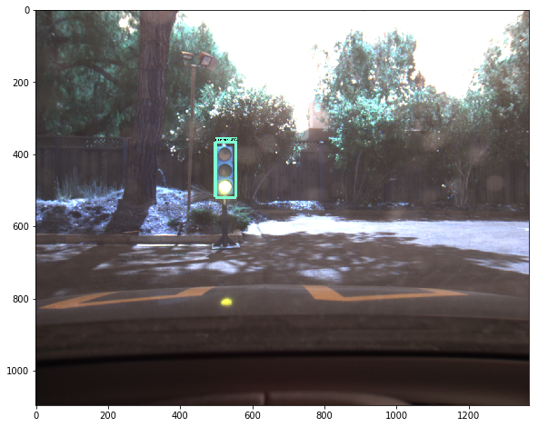

```python
PATH_TO_LABELS = src_dir + 'data/tl_label_map.pbtxt'
GRAPH_FILE = src_dir + "tl_classification_final/frozen_inference_graph.pb"
NUM_CLASSES = 5

class2 = Classifier()
class2.get_classification(Image.open(test_images[0]))
```

This trained model is able to locate the traffic light in a image and classify its color.

## Testing on videos

[ go back to the top ]

```python
# Import everything needed to edit/save/watch video clips
from moviepy.editor import VideoFileClip, ImageSequenceClip
from IPython.display import HTML
import glob
```

### Image to Video

[ go back to the top ]

We first conbine all images into a video, and we have two videos: just_traffic_light.mp4 and loop_with_traffic_light.mp4 after running the code below.

```python
def image_to_video(images_folder):
    # list of image paths
    myfiles = glob.glob(images_folder+"/*.png")
    myfiles.sort()
    # combine images to a video
    foutput = 'video/' + images_folder + '.mp4'
    clip = ImageSequenceClip(myfiles, load_images=True, fps=25)
    # output a video
    clip.write_videofile(foutput)
```

```python
image_to_video(src_dir_1)
image_to_video(src_dir_2)
```

### Video Pipeline

[ go back to the top ]

We created the pipeline below to detect and classify traffic light in videos, the results are promising.

```python
finput1 = 'video/' + src_dir_1 + '.mp4'
foutput1 = 'video/' + src_dir_1 + '_detection.mp4'

finput2 = 'video/' + src_dir_2 + '.mp4'
foutput2 = 'video/' + src_dir_2 + '_detection.mp4'
```

```python
def pipeline(img):
    # the array based representation of the image will be used later in order to prepare the
    # result image with boxes and labels on it.
    draw_img = img
    # Expand dimensions since the model expects images to have shape: [1, None, None, 3]
    # Actual detection.
    (boxes, scores, classes, num) = sess.run([detection_boxes,
                                              detection_scores,
                                              detection_classes,
                                              num_detections],
                                             feed_dict={image_tensor: np.expand_dims(img, 0)})
    # Visualization of the results of a detection.
    vis_util.visualize_boxes_and_labels_on_image_array(draw_img,np.squeeze(boxes),
                                                       np.squeeze(classes).astype(np.int32),
                                                       np.squeeze(scores),
                                                       category_index,
                                                       use_normalized_coordinates=True,
                                                       line_thickness=8)
    return draw_img
```

```python
with tf.Session(graph=detection_graph) as sess:
    # Definite input and output Tensors for detection_graph
    image_tensor = detection_graph.get_tensor_by_name('image_tensor:0')
    # Each box represents a part of the image where a particular object was detected.
    detection_boxes = detection_graph.get_tensor_by_name('detection_boxes:0')
    # Each score represent how level of confidence for each of the objects.
    # Score is shown on the result image, together with the class label.
    detection_scores = detection_graph.get_tensor_by_name('detection_scores:0')
    detection_classes = detection_graph.get_tensor_by_name('detection_classes:0')
    num_detections = detection_graph.get_tensor_by_name('num_detections:0')

    clip = VideoFileClip(finput1)
    print("video size: ", clip.size)
    new_clip = clip.fl_image(pipeline)
    %time new_clip.write_videofile(foutput1, audio=False)
```

[output not shown]

```python
HTML("""
<video width="700" height="600" controls>
  <source src="{0}" type="video/mp4">
</video>
""".format('https://github.com/wzding/Electric_Eel_Capstone/blob/master/video/just_traffic_light_detection.mp4?raw=true'))
```

[video not shown]

```python
with tf.Session(graph=detection_graph) as sess:
    # Definite input and output Tensors for detection_graph
    image_tensor = detection_graph.get_tensor_by_name('image_tensor:0')
    # Each box represents a part of the image where a particular object was detected.
    detection_boxes = detection_graph.get_tensor_by_name('detection_boxes:0')
    # Each score represent how level of confidence for each of the objects.
    # Score is shown on the result image, together with the class label.
    detection_scores = detection_graph.get_tensor_by_name('detection_scores:0')
    detection_classes = detection_graph.get_tensor_by_name('detection_classes:0')
    num_detections = detection_graph.get_tensor_by_name('num_detections:0')

    clip = VideoFileClip(finput2)
    print("video size: ", clip.size)
    new_clip = clip.fl_image(pipeline)
    %time new_clip.write_videofile(foutput2, audio=False)
```

[output not shown]

```python
HTML("""
<video width="700" height="600" controls>
  <source src="{0}" type="video/mp4">
</video>
""".format('https://github.com/wzding/Electric_Eel_Capstone/blob/master/video/loop_with_traffic_light_detection.mp4?raw=true'))
```

[video not shown]

## Resources

[ go back to the top ]

A few resources I have used in this project are:

detection: https://becominghuman.ai/tensorflow-object-detection-api-tutorial-training-and-evaluating-custom-object-detector-ed2594afcf73

classification: https://medium.com/@WuStangDan/step-by-step-tensorflow-object-detection-api-tutorial-part-2-converting-dataset-to-tfrecord-47f24be9248d

https://medium.com/@WuStangDan/step-by-step-tensorflow-object-detection-api-tutorial-part-4-training-the-model-68a9e5d5a333

https://medium.com/@WuStangDan/step-by-step-tensorflow-object-detection-api-tutorial-part-5-saving-and-deploying-a-model-8d51f56dbcf1

https://becominghuman.ai/tensorflow-object-detection-api-tutorial-training-and-evaluating-custom-object-detector-ed2594afcf73

Tutorial: https://pythonprogramming.net/creating-tfrecord-files-tensorflow-object-detection-api-tutorial/?completed=/custom-objects-tracking-tensorflow-object-detection-api-tutorial/

https://pythonprogramming.net/creating-tfrecord-files-tensorflow-object-detection-api-tutorial/